# Title: Image Classification using AWS Sagemaker

This notebook lists all the steps that you need to complete the complete this project. You will need to complete all the TODOs in this notebook as well as in the README and the two python scripts included with the starter code.

**Note:** This notebook has a bunch of code and markdown cells with TODOs that you have to complete. These are meant to be helpful guidelines for you to finish your project while meeting the requirements in the project rubrics. Feel free to change the order of these the TODO's and use more than one TODO code cell to do all your tasks.

```python
%%capture
!pip install smdebug torch --no-cache-dir
!pip install pytorch
!pip install torchvision
```

```python
# TODO: Import any packages that you might need
# For instance you will need Boto3 and Sagemaker
import sagemaker
import boto3
import torch
import torchvision
import os

from sagemaker.tuner import CategoricalParameter, ContinuousParameter, HyperparameterTuner
from sagemaker.pytorch import PyTorch
from sagemaker import get_execution_role
from sagemaker.debugger import Rule, DebuggerHookConfig, TensorBoardOutputConfig, CollectionConfig, ProfilerRule, rule_configs
from sagemaker.debugger import ProfilerConfig, FrameworkProfile
```

## Dataset

```python
#Fetch and upload the data to AWS S3
sagemaker_session = sagemaker.Session()
role = sagemaker.get_execution_role()
region = "us-east-1"
```

```python
# use default S3 bucket
bucket = sagemaker_session.default_bucket()

import os
# Upload data to S3 bucket.
os.environ["DEFAULT_S3_BUCKET"] = bucket
bucket
```

```
'sagemaker-us-east-1-953953830980'
```

```python
%%capture
!wget  https://s3-us-west-1.amazonaws.com/udacity-aind/dog-project/dogImages.zip
```

```python
%%capture
!unzip -o dogImages.zip
```

```python
%%capture
!aws s3 sync ./dogImages s3://${DEFAULT_S3_BUCKET}/dogImages/
```

## Hyperparameter Tuning

**TODO:** This is the part where you will finetune a pretrained model with hyperparameter tuning. Remember that you have to tune a minimum of two hyperparameters. However you are encouraged to tune more. You are also encouraged to explain why you chose to tune those particular hyperparameters and the ranges.

**Note:** You will need to use the `hpo.py` script to perform hyperparameter tuning.

```python
#TODO: Declare your HP ranges, metrics etc.
hyperparameter_ranges = {
    "learning_rate": ContinuousParameter(0.001, 0.1),
    "batch_size": CategoricalParameter([32, 64, 128, 256]),
}

role = sagemaker.get_execution_role()

objective_metric_name = "Test Loss"
objective_type = "Minimize"
metric_definitions = [{"Name": "Test Loss", "Regex": "Testing Loss: ([0-9\\.]+)"}]
```

```python
#TODO: Create estimators for your HPs
estimator = PyTorch(
    entry_point="hpo.py",
    base_job_name = 'pytorch_dog_hpo',
    role=role,
    py_version='py3',
    framework_version="1.8.0",
    instance_count=1,
    instance_type="ml.c5.xlarge"
    )

tuner = HyperparameterTuner(
    estimator,
    objective_metric_name,
    hyperparameter_ranges,
    metric_definitions,
    max_jobs=2,
    max_parallel_jobs=4,
    objective_type=objective_type,
)
```

```python
# TODO: Fit your HP Tuner
os.environ['SM_CHANNEL_TRAINING']='s3://sagemaker-us-east-1-953953830980/dogImages/'
os.environ['SM_MODEL_DIR']='s3://sagemaker-us-east-1-953953830980/model/'
os.environ['SM_OUTPUT_DATA_DIR']='s3://sagemaker-us-east-1-953953830980/output/'
tuner.fit({"training": "s3://sagemaker-us-east-1-953953830980/dogImages/"}, wait=True)# Remember to include your data channels
```

```
...........................................................
```

```python
# TODO: Get the best estimators and the best HPs

best_estimator = tuner.best_estimator()#TODO

#Get the hyperparameters of the best trained model
best_estimator.hyperparameters()
```

[output not shown]

## Model Profiling and Debugging

TODO: Using the best hyperparameters, create and finetune a new model

**Note:** You will need to use the `train_model.py` script to perform model profiling and debugging.

```python
from sagemaker.debugger import Rule, ProfilerRule, rule_configs, CollectionConfig
from sagemaker.debugger import DebuggerHookConfig, ProfilerConfig, FrameworkProfile

loss_not_decreasing_rule = Rule.sagemaker(base_config=rule_configs.loss_not_decreasing(),
                         rule_parameters={"tensor_regex": "CrossEntropyLoss_output_0",
                                         "mode": "TRAIN"})

rules = [
    loss_not_decreasing_rule,
    Rule.sagemaker(rule_configs.vanishing_gradient()),
    Rule.sagemaker(rule_configs.overfit()),
    Rule.sagemaker(rule_configs.overtraining()),
    Rule.sagemaker(rule_configs.poor_weight_initialization()),
    ProfilerRule.sagemaker(rule_configs.ProfilerReport()),

]
collection_configs=[CollectionConfig(name="CrossEntropyLoss_output_0",parameters={
    "include_regex": "CrossEntropyLoss_output_0", "train.save_interval": "10","eval.save_interval": "1"})]

profiler_config = ProfilerConfig(
    system_monitor_interval_millis=500, framework_profile_params=FrameworkProfile(num_steps=1)
)
debugger_config=DebuggerHookConfig(
    collection_configs=collection_configs
)
```

```python
hyperparameters = {"batch_size": int(best_estimator.hyperparameters()['batch_size'].replace('"', '')), \
                   "learning_rate": best_estimator.hyperparameters()['learning_rate']}

#yperparameters = {"batch_size": "32", "lr": "0.0033394403406322728"}
estimator = PyTorch(
    role=sagemaker.get_execution_role(),
    instance_count=1,
    instance_type='ml.m5.2xlarge',
    entry_point="train_model.py",
    framework_version="1.8.0",
    py_version="py3",
    hyperparameters=hyperparameters,
    profiler_config=profiler_config,
    debugger_hook_config=debugger_config,
    rules=rules
)
estimator.fit({"training": "s3://" +str(bucket)+"/dogImages/"}, wait=True)
```

[output not shown]

[output cut: 100 more lines]

```
Downloading: "https://download.pytorch.org/models/resnet50-19c8e357.pth" to /root/.cache/torch/hub/checkpoints/resnet50-19c8e357.pth
INFO:__main__:Start Model Training
INFO:__main__:Epoch:0
INFO:__main__:train loss: 1163.0000, acc: 1.0000, best loss: 1000000.0000
INFO:__main__:valid loss: 581.0000, acc: 1.0000, best loss: 581.0000
INFO:__main__:Testing Model
INFO:__main__:
Test set: Average loss: 581.0000, Accuracy: 1.0
INFO:__main__:Saving Model
2021-12-13 14:25:43,302 sagemaker-training-toolkit INFO     Reporting training SUCCESS

2021-12-13 14:26:08 Uploading - Uploading generated training model
2021-12-13 14:26:08 Completed - Training job completed
Training seconds: 906
Billable seconds: 906
```

```python
training_job_name = estimator.latest_training_job.name
print(f"Training jobname: {training_job_name}")
print(f"Region: {region}")

from smdebug.trials import create_trial
from smdebug.core.modes import ModeKeys

trial = create_trial(estimator.latest_job_debugger_artifacts_path())

print(trial.tensor_names())
print(len(trial.tensor('CrossEntropyLoss_output_0').steps(mode=ModeKeys.TRAIN)))
print(len(trial.tensor('CrossEntropyLoss_output_0').steps(mode=ModeKeys.EVAL)))
```

```
Training jobname: pytorch-training-2021-12-13-14-08-30-035
Region: us-east-1
[2021-12-13 14:26:35.257 datascience-1-0-ml-t3-medium-1abf3407f667f989be9d86559395:23 INFO s3_trial.py:42] Loading trial debug-output at path s3://sagemaker-us-east-1-953953830980/pytorch-training-2021-12-13-14-08-30-035/debug-output
[2021-12-13 14:26:36.115 datascience-1-0-ml-t3-medium-1abf3407f667f989be9d86559395:23 INFO trial.py:198] Training has ended, will refresh one final time in 1 sec.
[2021-12-13 14:26:37.135 datascience-1-0-ml-t3-medium-1abf3407f667f989be9d86559395:23 INFO trial.py:210] Loaded all steps
['CrossEntropyLoss_output_0', 'gradient/ResNet_fc.0.bias', 'gradient/ResNet_fc.0.weight', 'gradient/ResNet_fc.2.bias', 'gradient/ResNet_fc.2.weight', 'layer1.0.relu_input_0', 'layer1.0.relu_input_1', 'layer1.0.relu_input_2', 'layer1.1.relu_input_0', 'layer1.1.relu_input_1', 'layer1.1.relu_input_2', …
6
14
```

```python
def get_data(trial, tname, mode):
    tensor = trial.tensor(tname)
    steps = tensor.steps(mode=mode)
    vals = []
    for s in steps:
        vals.append(tensor.value(s, mode=mode))
    return steps, vals
```

```python
# TODO: Plot a debugging output.

import matplotlib.pyplot as plt
from mpl_toolkits.axes_grid1 import host_subplot


def plot_tensor(trial, tensor_name):

    steps_train, vals_train = get_data(trial, tensor_name, mode=ModeKeys.TRAIN)
    print("loaded TRAIN data")
    steps_eval, vals_eval = get_data(trial, tensor_name, mode=ModeKeys.EVAL)
    print("loaded EVAL data")

    fig = plt.figure(figsize=(10, 7))
    host = host_subplot(111)

    par = host.twiny()

    host.set_xlabel("Steps (TRAIN)")
    par.set_xlabel("Steps (EVAL)")
    host.set_ylabel(tensor_name)

    (p1,) = host.plot(steps_train, vals_train, label=tensor_name)
    print("completed TRAIN plot")
    (p2,) = par.plot(steps_eval, vals_eval, label="val_" + tensor_name)
    print("completed EVAL plot")
    leg = plt.legend()

    host.xaxis.get_label().set_color(p1.get_color())
    leg.texts[0].set_color(p1.get_color())

    par.xaxis.get_label().set_color(p2.get_color())
    leg.texts[1].set_color(p2.get_color())

    plt.ylabel(tensor_name)

    plt.show()
```

```
loaded TRAIN data
loaded EVAL data
completed TRAIN plot
completed EVAL plot
```

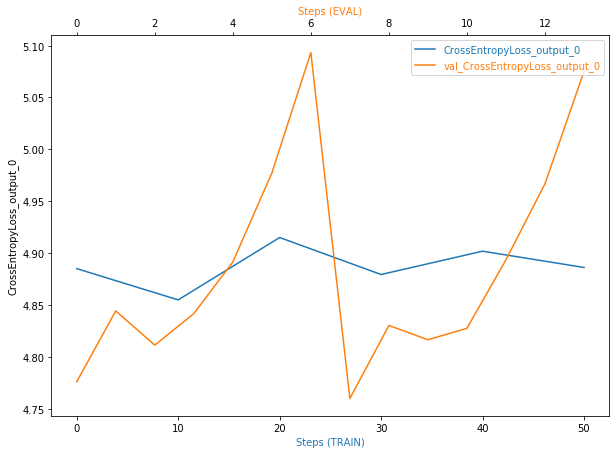

```python
plot_tensor(trial, "CrossEntropyLoss_output_0")
```

Is there some anomalous behaviour in your debugging output? If so, what is the error and how will you fix it?

If not, suppose there was an error. What would that error look like and how would you have fixed it?

check the debug output.

```python
# TODO: Display the profiler output
rule_output_path = estimator.output_path + estimator.latest_training_job.job_name + "/rule-output"
print(f"You will find the profiler report in {rule_output_path}")
```

```
You will find the profiler report in s3://sagemaker-us-east-1-953953830980/pytorch-training-2021-12-13-14-08-30-035/rule-output
```

```python
! aws s3 ls {rule_output_path} --recursive
```

```
2021-12-13 14:26:01     364310 pytorch-training-2021-12-13-14-08-30-035/rule-output/ProfilerReport/profiler-output/profiler-report.html
2021-12-13 14:26:00     211373 pytorch-training-2021-12-13-14-08-30-035/rule-output/ProfilerReport/profiler-output/profiler-report.ipynb
2021-12-13 14:25:57        192 pytorch-training-2021-12-13-14-08-30-035/rule-output/ProfilerReport/profiler-output/profiler-reports/BatchSize.json
2021-12-13 14:25:57        200 pytorch-training-2021-12-13-14-08-30-035/rule-output/ProfilerReport/profiler-output/profiler-reports/CPUBottleneck.json
2021-12-13 14:25:57       1673 pytorch-training-2021-12-13-14-08-30-035/rule-output/ProfilerReport/profiler-output/profiler-reports/Dataloader.json
2021-12-13 14:25:57        127 pytorch-training-2021-12-13-14-08-30-035/rule-output/ProfilerReport/profiler-output/profiler-reports/GPUMemoryIncrease.json
2021-12-13 14:25:57        199 pytorch-training-2021-12-13-14-08-30-035/rule-output/ProfilerReport/profiler-output/profiler-reports/IOBottleneck.json
2021-12-13 14:25:57        119 pytorch-training-2021-12-13-14-08-30-035/rule-output/ProfilerReport/profiler-output/profiler-reports/LoadBalancing.json
2021-12-13 14:25:57        151 pytorch-training-2021-12-13-14-08-30-035/rule-output/ProfilerReport/profiler-output/profiler-reports/LowGPUUtilization.json
2021-12-13 14:25:57        231 pytorch-training-2021-12-13-14-08-30-035/rule-output/ProfilerReport/profiler-output/profiler-reports/MaxInitializationTime.json
2021-12-13 14:25:57       1206 pytorch-training-2021-12-13-14-08-30-035/rule-output/ProfilerReport/profiler-output/profiler-reports/OverallFrameworkMetrics.json
2021-12-13 14:25:57        466 pytorch-training-2021-12-13-14-08-30-035/rule-output/ProfilerReport/profiler-output/profiler-reports/OverallSystemUsage.json
2021-12-13 14:25:57        157 pytorch-training-2021-12-13-14-08-30-035/rule-output/ProfilerReport/profiler-output/profiler-reports/StepOutlier.json
```

```python
! aws s3 cp {rule_output_path} ./ --recursive
```

[output not shown]

```python
import os

# get the autogenerated folder name of profiler report
profiler_report_name = [
    rule["RuleConfigurationName"]
    for rule in estimator.latest_training_job.rule_job_summary()
    if "Profiler" in rule["RuleConfigurationName"]
][0]
```

```python
import IPython

IPython.display.HTML(filename=profiler_report_name + "/profiler-output/profiler-report.html")
```

SageMaker Debugger Profiling Report

SageMaker Debugger auto generated this report. You can generate similar reports on all supported training jobs. The report provides summary of training job, system resource usage statistics, framework metrics, rules summary, and detailed analysis from each rule. The graphs and tables are interactive.

**Legal disclaimer:** This report and any recommendations are provided for informational purposes only and are not definitive. You are responsible for making your own independent assessment of the information.

```
# Parameters
processing_job_arn = "arn:aws:sagemaker:us-east-1:953953830980:processing-job/pytorch-training-2021-12-1-profilerreport-51191597"
```

Training job summary

[interactive chart not shown]

System usage statistics

[interactive chart not shown]

Framework metrics summary

[interactive chart not shown]

Overview: CPU operators

[interactive chart not shown]

Rules summary

The following table shows a profiling summary of the Debugger built-in rules. The table is sorted by the rules that triggered the most frequently. During your training job, the LoadBalancing rule was the most frequently triggered. It processed 0 datapoints and was triggered 0 times.

|  | Description | Recommendation | Number of times rule triggered | Number of datapoints | Rule parameters |
| --- | --- | --- | --- | --- | --- |
| LoadBalancing | Detects workload balancing issues across GPUs. Workload imbalance can occur in training jobs with data parallelism. The gradients are accumulated on a primary GPU, and this GPU might be overused with … | Choose a different distributed training strategy or a different distributed training framework. | 0 | 0 | threshold:0.2 patience:1000 |
| IOBottleneck | Checks if the data I/O wait time is high and the GPU utilization is low. It might indicate IO bottlenecks where GPU is waiting for data to arrive from storage. The rule evaluates the I/O and GPU utili… | Pre-fetch data or choose different file formats, such as binary formats that improve I/O performance. | 0 | 1671 | threshold:50 io_threshold:50 gpu_threshold:10 patience:1000 |
| Dataloader | Checks how many data loaders are running in parallel and whether the total number is equal the number of available CPU cores. The rule triggers if number is much smaller or larger than the number of a… | Change the number of data loader processes. | 0 | 1 | min_threshold:70 max_threshold:200 |
| CPUBottleneck | Checks if the CPU utilization is high and the GPU utilization is low. It might indicate CPU bottlenecks, where the GPUs are waiting for data to arrive from the CPUs. The rule evaluates the CPU and GPU… | Consider increasing the number of data loaders or applying data pre-fetching. | 0 | 1671 | threshold:50 cpu_threshold:90 gpu_threshold:10 patience:1000 |
| MaxInitializationTime | Checks if the time spent on initialization exceeds a threshold percent of the total training time. The rule waits until the first step of training loop starts. The initialization can take longer if do… | Initialization takes too long. If using File mode, consider switching to Pipe mode in case you are using TensorFlow framework. | 0 | 71 | threshold:20 |
| StepOutlier | Detects outliers in step duration. The step duration for forward and backward pass should be roughly the same throughout the training. If there are significant outliers, it may indicate a system stall… | Check if there are any bottlenecks (CPU, I/O) correlated to the step outliers. | 0 | 71 | threshold:3 mode:None n_outliers:10 stddev:3 |
| LowGPUUtilization | Checks if the GPU utilization is low or fluctuating. This can happen due to bottlenecks, blocking calls for synchronizations, or a small batch size. | Check if there are bottlenecks, minimize blocking calls, change distributed training strategy, or increase the batch size. | 0 | 0 | threshold_p95:70 threshold_p5:10 window:500 patience:1000 |
| GPUMemoryIncrease | Measures the average GPU memory footprint and triggers if there is a large increase. | Choose a larger instance type with more memory if footprint is close to maximum available memory. | 0 | 0 | increase:5 patience:1000 window:10 |
| BatchSize | Checks if GPUs are underutilized because the batch size is too small. To detect this problem, the rule analyzes the average GPU memory footprint, the CPU and the GPU utilization. | The batch size is too small, and GPUs are underutilized. Consider running on a smaller instance type or increasing the batch size. | 0 | 1665 | cpu_threshold_p95:70 gpu_threshold_p95:70 gpu_memory_threshold_p95:70 patience:1000 window:500 |

Analyzing the training loop

Step duration analysis

[interactive chart not shown]

GPU utilization analysis

**Usage per GPU**

[interactive chart not shown]

**Workload balancing**

[interactive chart not shown]

Dataloading analysis

[interactive chart not shown]

Batch size

[interactive chart not shown]

CPU bottlenecks

[interactive chart not shown]

I/O bottlenecks

[interactive chart not shown]

GPU memory

[interactive chart not shown]

[figure not shown]

## Model Deploying

```python
model_location=estimator.model_data
```

```python
import sagemaker
import boto3
from sagemaker.tuner import CategoricalParameter, ContinuousParameter, HyperparameterTuner
from sagemaker.pytorch import PyTorch
from sagemaker import get_execution_role
from sagemaker.debugger import Rule, DebuggerHookConfig, TensorBoardOutputConfig, CollectionConfig, ProfilerRule, rule_configs
from sagemaker.debugger import ProfilerConfig, FrameworkProfile

from sagemaker.pytorch import PyTorchModel
from sagemaker.predictor import Predictor
```

```python
jpeg_serializer = sagemaker.serializers.IdentitySerializer("image/jpeg")
json_deserializer = sagemaker.deserializers.JSONDeserializer()


class ImagePredictor(Predictor):
    def __init__(self, endpoint_name, sagemaker_session):
        super(ImagePredictor, self).__init__(
            endpoint_name,
            sagemaker_session=sagemaker_session,
            serializer=jpeg_serializer,
            deserializer=json_deserializer,
        )
```

```python
pytorch_model = PyTorchModel(model_data=model_location, role=role, entry_point='inference.py',py_version='py3',
                             framework_version='1.8',
                             predictor_cls=ImagePredictor)
```

```python
# TODO: Deploy your model to an endpoint

predictor=pytorch_model.deploy(initial_instance_count=1, instance_type="ml.c5.xlarge") #  Add your deployment configuration like instance type and number of instance
```

```
-----!
```

```python
with open("dogImages/test/010.Anatolian_shepherd_dog/Anatolian_shepherd_dog_00695.jpg", "rb") as f:
    payload = f.read()

type(payload)
```

```
bytes
```

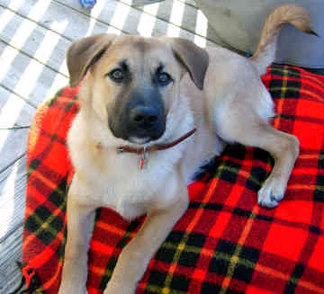

```python
from PIL import Image
import io
Image.open(io.BytesIO(payload))
```

```python
response=predictor.predict(payload, initial_args={"ContentType": "image/jpeg"})
```

```python
response
```

[output not shown]

[output cut: 78 more lines]

[output not shown]

```python
#Remember to shutdown/delete your endpoint once your work is done
#predictor.delete_endpoint()
```